# Tugas Pertemuan 3

Uiwang Nur Thoriq

2023-09-18

# Pemanggilan library dan import data

Peubah penjelas yang digunakan adalah PM25 dan peubah responnya Air Quality Indeks (AQI)

```r
library(dLagM)
library(dynlm)
library(MLmetrics)
library(lmtest)
library(car)
library(rio)
dataprt3<-import("https://raw.githubusercontent.com/UiwangNT/Praktikum_MPDW/main/pertemuan%203/dataprt3.csv")
dataprt3
```

```
##     t  AQI AQI(t-1)     PM25
## 1   1 30.2       NA 5.637410
## 2   2 28.2     30.2 4.618169
## 3   3 26.6     28.2 3.520902
## 4   4 25.0     26.6 2.225919
## 5   5 26.0     25.0 1.979471
## 6   6 26.0     26.0 1.792677
## 7   7 26.0     26.0 1.752237
## 8   8 24.0     26.0 1.858459
## 9   9 23.0     24.0 2.208076
## 10 10 24.0     23.0 2.476681
## 11 11 25.0     24.0 2.585729
## 12 12 26.0     25.0 2.390081
## 13 13 27.0     26.0 2.086022
## 14 14 29.0     27.0 1.937047
```

[output cut: 58 more lines]

#Split data menjadi data train dan data test dan membuatnya menjadi data time series

```r
nrow(dataprt3)
```

```
## [1] 72
```

```r
latih<-dataprt3[1:58,]
uji<-dataprt3[59:72,]
latih.ts<-ts(latih)
latih.ts
```

```
## Time Series:
## Start = 1
## End = 58
## Frequency = 1
##     t  AQI AQI(t-1)     PM25
##  1  1 30.2       NA 5.637410
##  2  2 28.2     30.2 4.618169
##  3  3 26.6     28.2 3.520902
##  4  4 25.0     26.6 2.225919
##  5  5 26.0     25.0 1.979471
##  6  6 26.0     26.0 1.792677
##  7  7 26.0     26.0 1.752237
##  8  8 24.0     26.0 1.858459
##  9  9 23.0     24.0 2.208076
## 10 10 24.0     23.0 2.476681
```

[output cut: 48 more lines]

```r
uji.ts<-ts(uji)
uji.ts
```

```
## Time Series:
## Start = 1
## End = 14
## Frequency = 1
##     t AQI AQI(t-1)     PM25
##  1 59  22       23 2.750613
##  2 60  21       22 2.984422
##  3 61  20       21 3.065950
##  4 62  19       20 3.118563
##  5 63  19       19 3.090378
##  6 64  20       19 2.976335
##  7 65  21       20 2.846886
##  8 66  21       21 2.771884
##  9 67  21       21 2.730851
## 10 68  22       21 2.720472
## 11 69  24       22 2.713109
## 12 70  26       24 2.743044
## 13 71  27       26 2.780022
## 14 72  28       27 2.745875
```

```r
dataprt3.ts<-ts(dataprt3)
dataprt3.ts
```

```
## Time Series:
## Start = 1
## End = 72
## Frequency = 1
##     t  AQI AQI(t-1)     PM25
##  1  1 30.2       NA 5.637410
##  2  2 28.2     30.2 4.618169
##  3  3 26.6     28.2 3.520902
##  4  4 25.0     26.6 2.225919
##  5  5 26.0     25.0 1.979471
##  6  6 26.0     26.0 1.792677
##  7  7 26.0     26.0 1.752237
##  8  8 24.0     26.0 1.858459
##  9  9 23.0     24.0 2.208076
## 10 10 24.0     23.0 2.476681
```

[output cut: 62 more lines]

#Pemodelan dengan model Koyck

```r
model.koyck <- koyckDlm(x = latih$PM25, y = latih$AQI)
summary(model.koyck)
```

```
##
## Call:
## "Y ~ (Intercept) + Y.1 + X.t"
##
## Residuals:
##      Min       1Q   Median       3Q      Max
## -2.14443 -0.61319  0.03512  0.48195  2.18725
##
## Coefficients:
##             Estimate Std. Error t value Pr(>|t|)
## (Intercept)   4.0771     1.8299   2.228   0.0301 *
## Y.1           0.8897     0.0588  15.131   <2e-16 ***
## X.t          -0.5723     0.2854  -2.005   0.0500 *
## ---
## Signif. codes:  0 '***' 0.001 '**' 0.01 '*' 0.05 '.' 0.1 ' ' 1
##
## Residual standard error: 0.9279 on 54 degrees of freedom
## Multiple R-Squared: 0.8273,  Adjusted R-squared: 0.8209
## Wald test: 129.1 on 2 and 54 DF,  p-value: < 2.2e-16
##
## Diagnostic tests:
## NULL
##
##                             alpha       beta       phi
## Geometric coefficients:  36.94716 -0.5722988 0.8896496
```

```r
AIC(model.koyck)
```

```
## [1] 158.1481
```

```r
BIC(model.koyck)
```

```
## [1] 166.3203
```

Berdasarkan hasil pemodelan didapatkan bahwa pada intercept, $x_t$ dan $y_{t-1}$ memiliki p-value yang < 0.05. Maka dapat disimpulkan bahwa intercept, $x_t$ dan $y_{t-1}$ berpengaruh signifikan terhadap $y_t$ dengan taraf 5%.

$$\hat{Y_t}=4.0771-0.5723X_t+0.8897Y_{t-1}$$

#Peramalan dan akurasi dengan metode Koyck Melakukan peramalan sebanyak 14 periode dan menghitung akurasi data latih

```r
peramalan.koyck <- forecast(model = model.koyck,x = uji$PM25, h=14)
peramalan.koyck
```

```
## $forecasts
##  [1] 22.96490 22.79987 22.60639 22.40415 22.24036 22.15991 22.16242 22.20757
##  [9] 22.27123 22.33380 22.39368 22.42982 22.44082 22.47014
##
## $call
## forecast.koyckDlm(model = model.koyck, x = uji$PM25, h = 14)
##
## attr(,"class")
## [1] "forecast.koyckDlm" "dLagM"
```

```r
mape.koyck <- MAPE(peramalan.koyck$forecasts, uji$AQI)

#akurasi data latih
GoF(model.koyck)
```

```
##              n       MAE          MPE       MAPE      sMAPE     MASE       MSE
## model.koyck 57 0.6909776 -0.001122737 0.02589331 0.02582947 1.040181 0.8157075
##                  MRAE    GMRAE
## model.koyck 757377131 11372.75
```

Pada hasil akurasi didapatkan nilai MAPE sebesar 0.02589331 < 10% yang berarti model yang dihasilkan dengan metode Koyck sudah baik.

#Regresi dengan Distributed Lag Pertama akan dilakukan uji coba (memilih lag bebas)

#Pemodelan dengan lag=4

```r
model.dist.lag <- dlm(x = latih$PM25,y = latih$AQI , q = 4)
summary(model.dist.lag)
```

```
##
## Call:
## lm(formula = model.formula, data = design)
##
## Residuals:
##     Min      1Q  Median      3Q     Max
## -2.7812 -1.0326  0.0037  0.8411  3.6452
##
## Coefficients:
##             Estimate Std. Error t value Pr(>|t|)
## (Intercept)  37.9512     1.7983  21.104  < 2e-16 ***
## x.t         -12.2936     2.5526  -4.816  1.5e-05 ***
## x.1           7.3378     3.8836   1.889   0.0649 .
## x.2           0.4926     3.1977   0.154   0.8782
## x.3           1.2347     2.9723   0.415   0.6797
## x.4          -2.0250     1.3743  -1.473   0.1472
## ---
## Signif. codes:  0 '***' 0.001 '**' 0.01 '*' 0.05 '.' 0.1 ' ' 1
##
## Residual standard error: 1.575 on 48 degrees of freedom
## Multiple R-squared:  0.5479, Adjusted R-squared:  0.5009
## F-statistic: 11.64 on 5 and 48 DF,  p-value: 2.156e-07
##
## AIC and BIC values for the model:
##        AIC      BIC
## 1 209.9314 223.8543
```

```r
AIC(model.dist.lag)
```

```
## [1] 209.9314
```

```r
BIC(model.dist.lag)
```

```
## [1] 223.8543
```

Berdasarkan hasil pemodelan, diperoleh nilai p-value pada intercept dan $x_t$ yang < 0.05. Maka dapat disimpulkan bahwa intercept dan peubah $x_t$ berpengaruh signifikan terhadap $y_t$

$$\hat{Y_t}=37.9512-12.2936X_t+7.3378X_{t-1}+0.4926X_{t-2}+1.2347X_{t-3}-2.0250X_{t-4}$$
#Peramalan dan Akurasi dengan distributed lag Dilakukan peramalan untuk 14 periode

```r
ramal.dist.lag <- forecast(model = model.dist.lag, x=uji$PM25, h=14)
ramal.dist.lag
```

```
## $forecasts
##  [1] 21.98609 21.17325 22.08579 21.91174 22.46775 23.31605 23.95661 23.73128
##  [9] 23.53787 23.39854 23.56221 23.23628 23.06799 23.78578
##
## $call
## forecast.dlm(model = model.dist.lag, x = uji$PM25, h = 14)
##
## attr(,"class")
## [1] "forecast.dlm" "dLagM"
```

```r
mape.dist.lag <- MAPE(ramal.dist.lag$forecasts, uji$AQI)

#akurasi data training
GoF(model.dist.lag)
```

```
##                 n      MAE          MPE       MAPE      sMAPE   MASE      MSE
## model.dist.lag 54 1.155685 -0.002806476 0.04184784 0.04179287 1.8561 2.204458
##                      MRAE    GMRAE
## model.dist.lag 5689201271 31881.26
```

# Mencari nilai lag optimum

```r
finiteDLMauto(formula = AQI ~ PM25,
              data = data.frame(latih), q.min = 1,q.max = 27,
              model.type = "dlm", error.type = "AIC", trace = FALSE)
```

```
##    q - k    MASE      AIC      BIC    GMRAE   MBRAE R.Adj.Sq    Ljung-Box
## 27    27 0.05202 -48.7592 -5.73959 774.6002 0.47258  0.99586 0.0003180612
```

Diperoleh nilai lag optimum yaitu 27 ketika nilai AIC = -48.7592

# Pemodelan dengan lag =27

```r
model.dist.lag2 <- dlm(x = latih$PM25,y = latih$AQI , q = 27)
summary(model.dist.lag2)
```

```
##
## Call:
## lm(formula = model.formula, data = design)
##
## Residuals:
##          1          2          3          4          5          6          7
## -0.0035965  0.0062541 -0.0039899 -0.0036755  0.0058525 -0.0103911  0.0139085
##          8          9         10         11         12         13         14
## -0.0058152 -0.0248841  0.0649721 -0.0696781  0.0493880  0.0002728 -0.0378489
##         15         16         17         18         19         20         21
## -0.0037366  0.0564823 -0.0439226 -0.0345891  0.0885951 -0.0416181 -0.0077524
##         22         23         24         25         26         27         28
## -0.0076482  0.0482537 -0.0368051 -0.0481653  0.0999554 -0.0811154  0.0347042
##         29         30         31
##  0.0017283 -0.0185521  0.0134171
##
## Coefficients:
##             Estimate Std. Error t value Pr(>|t|)
## (Intercept)  22.1466     9.4100   2.354   0.1428
## x.t         -13.4080     2.4498  -5.473   0.0318 *
## x.1          14.4554     6.3778   2.266   0.1516
## x.2         -10.1032    10.3497  -0.976   0.4319
## x.3           4.6136    10.7569   0.429   0.7098
## x.4           3.1305    10.9933   0.285   0.8026
## x.5          -4.7434    12.4117  -0.382   0.7391
## x.6           6.5397    10.7646   0.608   0.6053
## x.7           0.1571    10.9122   0.014   0.9898
## x.8          -9.9558    10.9447  -0.910   0.4590
## x.9           6.2886    12.6762   0.496   0.6690
## x.10          7.2272    14.3620   0.503   0.6648
## x.11         -5.8493     9.7920  -0.597   0.6109
## x.12          0.8492     8.5782   0.099   0.9302
## x.13         -5.9003     8.8478  -0.667   0.5735
## x.14          8.6972     9.7091   0.896   0.4649
## x.15          3.7111    10.9399   0.339   0.7668
## x.16        -30.5426    11.2455  -2.716   0.1130
## x.17         38.4127    11.9970   3.202   0.0853 .
## x.18        -28.2341     8.3050  -3.400   0.0767 .
## x.19         13.4275     6.7977   1.975   0.1869
## x.20          2.5450     5.5639   0.457   0.6923
## x.21         -8.2555     5.9255  -1.393   0.2982
## x.22         13.2621     4.7916   2.768   0.1095
## x.23         -9.2654     3.5848  -2.585   0.1227
## x.24          4.5406     2.9405   1.544   0.2625
## x.25          3.4704     1.6286   2.131   0.1668
## x.26         -5.0533     1.4669  -3.445   0.0749 .
## x.27          2.9227     0.6517   4.485   0.0463 *
## ---
## Signif. codes:  0 '***' 0.001 '**' 0.01 '*' 0.05 '.' 0.1 ' ' 1
##
## Residual standard error: 0.1649 on 2 degrees of freedom
## Multiple R-squared:  0.9997, Adjusted R-squared:  0.9959
## F-statistic: 258.5 on 28 and 2 DF,  p-value: 0.00386
##
## AIC and BIC values for the model:
##        AIC       BIC
## 1 -48.7592 -5.739587
```

```r
AIC(model.dist.lag2)
```

```
## [1] -48.7592
```

```r
BIC(model.dist.lag2)
```

```
## [1] -5.739587
```

Berdasarkan hasil pemodelan, diperoleh nilai p-value pada $x_t$ dan $x_{t-27}$ < 0.05. Maka dapat disimpulkan bahwa peubah $x_t$ dan $x_{t-27}$ berpengaruh signifikan terhadap $y$

#Peramalan dan akurasi dengan distributed lag optimum Meramal sebanyak 14 periode

```r
#peramalan dan akurasi
ramal.dist.lag2 <- forecast(model = model.dist.lag2, x=uji$PM25, h=14)
mape.dist.lag2<- MAPE(ramal.dist.lag2$forecasts, uji$AQI)
#akurasi data training
GoF(model.dist.lag2)
```

```
##                  n        MAE           MPE      MAPE       sMAPE       MASE
## model.dist.lag2 31 0.03121187 -2.924117e-06 0.0011775 0.001177694 0.05201979
##                        MSE      MRAE    GMRAE
## model.dist.lag2 0.00175333 125880550 774.6002
```

# Pemodelan dengan Autoregressive

```r
model.ardl <- ardlDlm(x = latih$PM25, y = latih$AQI, p = 1 , q = 1)
summary(model.ardl)
```

```
##
## Time series regression with "ts" data:
## Start = 2, End = 58
##
## Call:
## dynlm(formula = as.formula(model.text), data = data, start = 1)
##
## Residuals:
##      Min       1Q   Median       3Q      Max
## -2.14374 -0.61593  0.03152  0.47781  2.18777
##
## Coefficients:
##             Estimate Std. Error t value Pr(>|t|)
## (Intercept)  4.00535    2.07382   1.931   0.0588 .
## X.t         -0.52588    0.80265  -0.655   0.5152
## X.1         -0.03046    0.55965  -0.054   0.9568
## Y.1          0.89112    0.06338  14.060   <2e-16 ***
## ---
## Signif. codes:  0 '***' 0.001 '**' 0.01 '*' 0.05 '.' 0.1 ' ' 1
##
## Residual standard error: 0.9366 on 53 degrees of freedom
## Multiple R-squared:  0.8273, Adjusted R-squared:  0.8175
## F-statistic: 84.63 on 3 and 53 DF,  p-value: < 2.2e-16
```

```r
AIC(model.ardl)
```

```
## [1] 160.1445
```

```r
BIC(model.ardl)
```

```
## [1] 170.3598
```

Hasil pemodelan dengan ARDL menunjukkan bahwa p-value pada $y_{t-1}$ < 0.05. Maka dapat disimpulkan bahwa $y_{t-1}$ berpengaruh signifikan terhadap $y_t$.

$$\hat{Y}=4.00535-0.52588X_t-0.03046X_{t-1}+0.89112Y_{t-1}$$
#Peramalan dan akurasi dengan ARDL Meramal dengan ARDL sebanyak 14 periode

```r
ramal.ardl <- forecast(model = model.ardl, x=uji$PM25, h=14)
ramal.ardl
```

```
## $forecasts
##  [1] 22.97840 22.82860 22.64511 22.45145 22.29209 22.21092 22.21013 22.25281
##  [9] 22.31471 22.37658 22.43590 22.47324 22.48616 22.51451
##
## $call
## forecast.ardlDlm(model = model.ardl, x = uji$PM25, h = 14)
##
## attr(,"class")
## [1] "forecast.ardlDlm" "dLagM"
```

```r
mape.ardl <- MAPE(ramal.ardl$forecasts, uji$AQI)
mape.ardl
```

```
## [1] 0.1064417
```

```r
#akurasi data latih
GoF(model.ardl)
```

```
##             n       MAE          MPE       MAPE      sMAPE     MASE      MSE
## model.ardl 57 0.6903949 -0.001124168 0.02587044 0.02580646 1.039304 0.815656
##                 MRAE    GMRAE
## model.ardl 747650739 11295.89
```

Berdasarkan perhitungan akurasi terlihat bahwa nilai MAPE keduanya tidak jauh berbeda, yaitu 0.1064417 dengan 0.02587044. Artinya, model regresi dengan distribusi lag ini tidak overfitted atau underfitted.

#Menentukan lag optimum

```r
model.ardl.opt <- ardlBoundOrders(data = data.frame(dataprt3), ic = "AIC",
                                  formula = AQI ~ PM25 )
min_p=c()
for(i in 1:6){
  min_p[i]=min(model.ardl.opt$Stat.table[[i]])
}
q_opt=which(min_p==min(min_p, na.rm = TRUE))
p_opt=which(model.ardl.opt$Stat.table[[q_opt]] ==
              min(model.ardl.opt$Stat.table[[q_opt]], na.rm = TRUE))
data.frame("q_optimum" = q_opt, "p_optimum" = p_opt,
           "AIC"=model.ardl.opt$min.Stat)
```

```
##   q_optimum p_optimum      AIC
## 1         5        15 124.7089
```

#Pemodelan dengan p dan q optimum

```r
model.ardl2 <- ardlDlm(x = latih$PM25, y = latih$AQI, p = 15 , q = 5)
summary(model.ardl2)
```

```
##
## Time series regression with "ts" data:
## Start = 16, End = 58
##
## Call:
## dynlm(formula = as.formula(model.text), data = data, start = 1)
##
## Residuals:
##      Min       1Q   Median       3Q      Max
## -0.88057 -0.23581 -0.06586  0.20248  0.98471
##
## Coefficients:
##             Estimate Std. Error t value Pr(>|t|)
## (Intercept)   4.5999     7.0010   0.657  0.51829
## X.t          -8.9338     2.8664  -3.117  0.00522 **
## X.1          12.3455     7.4335   1.661  0.11161
## X.2           2.8008     9.3639   0.299  0.76780
## X.3          -0.8430     9.8047  -0.086  0.93229
## X.4          -7.1559     9.6048  -0.745  0.46451
## X.5           4.9291     9.1014   0.542  0.59381
## X.6          -3.4553     9.6425  -0.358  0.72366
## X.7          -2.0450     9.7699  -0.209  0.83622
## X.8          -0.3190     9.3072  -0.034  0.97298
## X.9           2.1609     8.4408   0.256  0.80044
## X.10          0.3885     7.5939   0.051  0.95968
## X.11         -0.7947     5.9062  -0.135  0.89425
## X.12          1.5020     3.8268   0.392  0.69865
## X.13         -0.5530     2.7671  -0.200  0.84352
## X.14         -1.6015     2.6911  -0.595  0.55813
## X.15          1.5886     1.4944   1.063  0.29984
## Y.1           0.6154     0.2067   2.977  0.00719 **
## Y.2           0.5880     0.2616   2.248  0.03547 *
## Y.3           0.1984     0.2573   0.771  0.44917
## Y.4          -0.2500     0.2446  -1.022  0.31837
## Y.5          -0.3217     0.2081  -1.546  0.13702
## ---
## Signif. codes:  0 '***' 0.001 '**' 0.01 '*' 0.05 '.' 0.1 ' ' 1
##
## Residual standard error: 0.5957 on 21 degrees of freedom
## Multiple R-squared:  0.9639, Adjusted R-squared:  0.9278
## F-statistic:  26.7 on 21 and 21 DF,  p-value: 9.365e-11
```

```r
AIC(model.ardl2)
```

```
## [1] 92.66528
```

```r
BIC(model.ardl2)
```

```
## [1] 133.1729
```

Hasil pemodelan dengan ARDL p dan q optimum menunjukkan bahwa p-value pada $x_t$, $y_{t-1}$ dan $y_{t-2}$ < 0.05. Maka dapat disimpulkan bahwa $x_t$, $y_{t-1}$ dan $y_{t-2}$ berpengaruh signifikan terhadap $y_t$.

# Peramalan dan akurasi ARDL optimum

Peramalan sebanyak 14 periode

```r
ramal.ardl2 <- forecast(model = model.ardl2, x=uji$PM25, h=14)
ramal.ardl2
```

```
## $forecasts
##  [1] 23.14974 23.85549 26.27149 28.24472 31.55274 34.11395 35.91482 35.73322
##  [9] 35.22439 33.58315 31.70727 29.31163 27.26310 25.95616
##
## $call
## forecast.ardlDlm(model = model.ardl2, x = uji$PM25, h = 14)
##
## attr(,"class")
## [1] "forecast.ardlDlm" "dLagM"
```

```r
mape.ardl2 <- MAPE(ramal.ardl2$forecasts, uji$AQI)
mape.ardl2
```

```
## [1] 0.3929756
```

```r
#akurasi data latih
GoF(model.ardl2)
```

```
##              n      MAE           MPE       MAPE     sMAPE      MASE       MSE
## model.ardl2 43 0.322001 -0.0002384617 0.01187065 0.0118753 0.5635018 0.1733161
##                   MRAE    GMRAE
## model.ardl2 1535111567 19348.06
```

# Pemodelan DLM & ARDL dengan Library `dynlm` sebagai contoh

```r
#sama dengan model dlm q=1
cons_lm1 <- dynlm(AQI ~ PM25+L(PM25),data = latih.ts)
#sama dengan model ardl p=1 q=0
cons_lm2 <- dynlm(AQI ~ PM25+L(AQI),data = latih.ts)
#sama dengan ardl p=1 q=1
cons_lm3 <- dynlm(AQI ~ PM25+L(PM25)+L(AQI),data = latih.ts)
#sama dengan dlm p=2
cons_lm4 <- dynlm(AQI ~ PM25+L(PM25)+L(PM25,2),data = latih.ts)

#Ringkasan model
summary(cons_lm1)
```

```
##
## Time series regression with "ts" data:
## Start = 2, End = 58
##
## Call:
## dynlm(formula = AQI ~ PM25 + L(PM25), data = latih.ts)
##
## Residuals:
##     Min      1Q  Median      3Q     Max
## -5.2450 -1.2419 -0.3730  0.9165  4.4062
##
## Coefficients:
##             Estimate Std. Error t value Pr(>|t|)
## (Intercept)   31.691      1.403  22.595  < 2e-16 ***
## PM25          -5.051      1.584  -3.188  0.00238 **
## L(PM25)        2.783      1.126   2.471  0.01665 *
## ---
## Signif. codes:  0 '***' 0.001 '**' 0.01 '*' 0.05 '.' 0.1 ' ' 1
##
## Residual standard error: 2.018 on 54 degrees of freedom
## Multiple R-squared:  0.1831, Adjusted R-squared:  0.1528
## F-statistic:  6.05 on 2 and 54 DF,  p-value: 0.004256
```

```r
summary(cons_lm2)
```

```
##
## Time series regression with "ts" data:
## Start = 2, End = 58
##
## Call:
## dynlm(formula = AQI ~ PM25 + L(AQI), data = latih.ts)
##
## Residuals:
##      Min       1Q   Median       3Q      Max
## -2.14287 -0.61263  0.03423  0.48242  2.18809
##
## Coefficients:
##             Estimate Std. Error t value Pr(>|t|)
## (Intercept)  4.05959    1.80178   2.253   0.0283 *
## PM25        -0.56700    0.26864  -2.111   0.0395 *
## L(AQI)       0.88989    0.05864  15.176   <2e-16 ***
## ---
## Signif. codes:  0 '***' 0.001 '**' 0.01 '*' 0.05 '.' 0.1 ' ' 1
##
## Residual standard error: 0.9279 on 54 degrees of freedom
## Multiple R-squared:  0.8273, Adjusted R-squared:  0.8209
## F-statistic: 129.3 on 2 and 54 DF,  p-value: < 2.2e-16
```

```r
summary(cons_lm3)
```

```
##
## Time series regression with "ts" data:
## Start = 2, End = 58
##
## Call:
## dynlm(formula = AQI ~ PM25 + L(PM25) + L(AQI), data = latih.ts)
##
## Residuals:
##      Min       1Q   Median       3Q      Max
## -2.14374 -0.61593  0.03152  0.47781  2.18777
##
## Coefficients:
##             Estimate Std. Error t value Pr(>|t|)
## (Intercept)  4.00535    2.07382   1.931   0.0588 .
## PM25        -0.52588    0.80265  -0.655   0.5152
## L(PM25)     -0.03046    0.55965  -0.054   0.9568
## L(AQI)       0.89112    0.06338  14.060   <2e-16 ***
## ---
## Signif. codes:  0 '***' 0.001 '**' 0.01 '*' 0.05 '.' 0.1 ' ' 1
##
## Residual standard error: 0.9366 on 53 degrees of freedom
## Multiple R-squared:  0.8273, Adjusted R-squared:  0.8175
## F-statistic: 84.63 on 3 and 53 DF,  p-value: < 2.2e-16
```

```r
summary(cons_lm4)
```

```
##
## Time series regression with "ts" data:
## Start = 3, End = 58
##
## Call:
## dynlm(formula = AQI ~ PM25 + L(PM25) + L(PM25, 2), data = latih.ts)
##
## Residuals:
##     Min      1Q  Median      3Q     Max
## -4.5504 -1.2693 -0.0678  1.0780  4.0378
##
## Coefficients:
##             Estimate Std. Error t value Pr(>|t|)
## (Intercept)   35.453      1.656  21.405  < 2e-16 ***
## PM25          -8.438      2.173  -3.883 0.000293 ***
## L(PM25)        6.515      3.189   2.043 0.046126 *
## L(PM25, 2)    -2.178      1.553  -1.403 0.166651
## ---
## Signif. codes:  0 '***' 0.001 '**' 0.01 '*' 0.05 '.' 0.1 ' ' 1
##
## Residual standard error: 1.84 on 52 degrees of freedom
## Multiple R-squared:  0.343,  Adjusted R-squared:  0.3051
## F-statistic: 9.048 on 3 and 52 DF,  p-value: 6.393e-05
```

# SSE

```r
deviance(cons_lm1)
```

```
## [1] 219.9153
```

```r
deviance(cons_lm2)
```

```
## [1] 46.49499
```

```r
deviance(cons_lm3)
```

```
## [1] 46.49239
```

```r
deviance(cons_lm4)
```

```
## [1] 176.0376
```

#Uji Diagnostik

```r
#uji model
if(require("lmtest")) encomptest(cons_lm1, cons_lm2)
```

```
## Encompassing test
##
## Model 1: AQI ~ PM25 + L(PM25)
## Model 2: AQI ~ PM25 + L(AQI)
## Model E: AQI ~ PM25 + L(PM25) + L(AQI)
##           Res.Df Df       F Pr(>F)
## M1 vs. ME     53 -1 197.697 <2e-16 ***
## M2 vs. ME     53 -1   0.003 0.9568
## ---
## Signif. codes:  0 '***' 0.001 '**' 0.01 '*' 0.05 '.' 0.1 ' ' 1
```

#Autokolerasi

```r
dwtest(cons_lm1)
```

```
##
##  Durbin-Watson test
##
## data:  cons_lm1
## DW = 0.3953, p-value = 1.217e-15
## alternative hypothesis: true autocorrelation is greater than 0
```

```r
dwtest(cons_lm2)
```

```
##
##  Durbin-Watson test
##
## data:  cons_lm2
## DW = 1.0689, p-value = 3.466e-05
## alternative hypothesis: true autocorrelation is greater than 0
```

```r
dwtest(cons_lm3)
```

```
##
##  Durbin-Watson test
##
## data:  cons_lm3
## DW = 1.0666, p-value = 2.263e-05
## alternative hypothesis: true autocorrelation is greater than 0
```

```r
dwtest(cons_lm4)
```

```
##
##  Durbin-Watson test
##
## data:  cons_lm4
## DW = 0.69805, p-value = 3.332e-09
## alternative hypothesis: true autocorrelation is greater than 0
```

Pada keempat model terdapat autokorelasi

#Heterogenitas

```r
bptest(cons_lm1)
```

```
##
##  studentized Breusch-Pagan test
##
## data:  cons_lm1
## BP = 10.715, df = 2, p-value = 0.004712
```

```r
bptest(cons_lm2)
```

```
##
##  studentized Breusch-Pagan test
##
## data:  cons_lm2
## BP = 0.62294, df = 2, p-value = 0.7324
```

```r
bptest(cons_lm3)
```

```
##
##  studentized Breusch-Pagan test
##
## data:  cons_lm3
## BP = 0.63463, df = 3, p-value = 0.8885
```

```r
bptest(cons_lm4)
```

```
##
##  studentized Breusch-Pagan test
##
## data:  cons_lm4
## BP = 15.495, df = 3, p-value = 0.001439
```

Ragam pada model 1 dan 4 heterogen

#Kenormalan

```r
shapiro.test(residuals(cons_lm1))
```

```
##
##  Shapiro-Wilk normality test
##
## data:  residuals(cons_lm1)
## W = 0.9602, p-value = 0.05818
```

```r
shapiro.test(residuals(cons_lm2))
```

```
##
##  Shapiro-Wilk normality test
##
## data:  residuals(cons_lm2)
## W = 0.97999, p-value = 0.4631
```

```r
shapiro.test(residuals(cons_lm3))
```

```
##
##  Shapiro-Wilk normality test
##
## data:  residuals(cons_lm3)
## W = 0.97953, p-value = 0.4439
```

```r
shapiro.test(residuals(cons_lm4))
```

```
##
##  Shapiro-Wilk normality test
##
## data:  residuals(cons_lm4)
## W = 0.9739, p-value = 0.2636
```

Semua model menyebar normal

# Perbandingan Model

Melakukan perbandingan nilai MAPE dari model-model yang telah dibuat di atas tadi (yang bukan contoh dengan Library `dynlm`)

```r
akurasi <- matrix(c(mape.koyck, mape.dist.lag, mape.dist.lag2, mape.ardl, mape.ardl2))
row.names(akurasi)<- c("Koyck","DLM 1","DLM 2","Autoregressive","Autoregressive 2")
colnames(akurasi) <- c("MAPE")
akurasi
```

```
##                       MAPE
## Koyck            0.1054825
## DLM 1            0.1064776
## DLM 2            0.2226026
## Autoregressive   0.1064417
## Autoregressive 2 0.3929756
```

Berdasarkan beberapa nilai MAPE dari metode-metode yang telah dicobakan, model paling optimum didapat pada Model Koyck karena memiliki nilai MAPE yang terkecil yaitu sebesar `0.1054825`.

#Plot

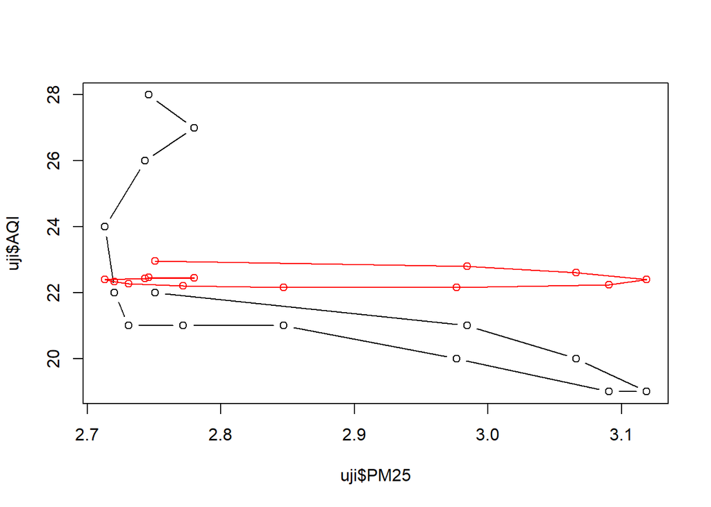

```r
plot(uji$PM25, uji$AQI, type="b", col="black")
points(uji$PM25, peramalan.koyck$forecasts,col="red")
lines(uji$PM25, peramalan.koyck$forecasts,col="red")
```

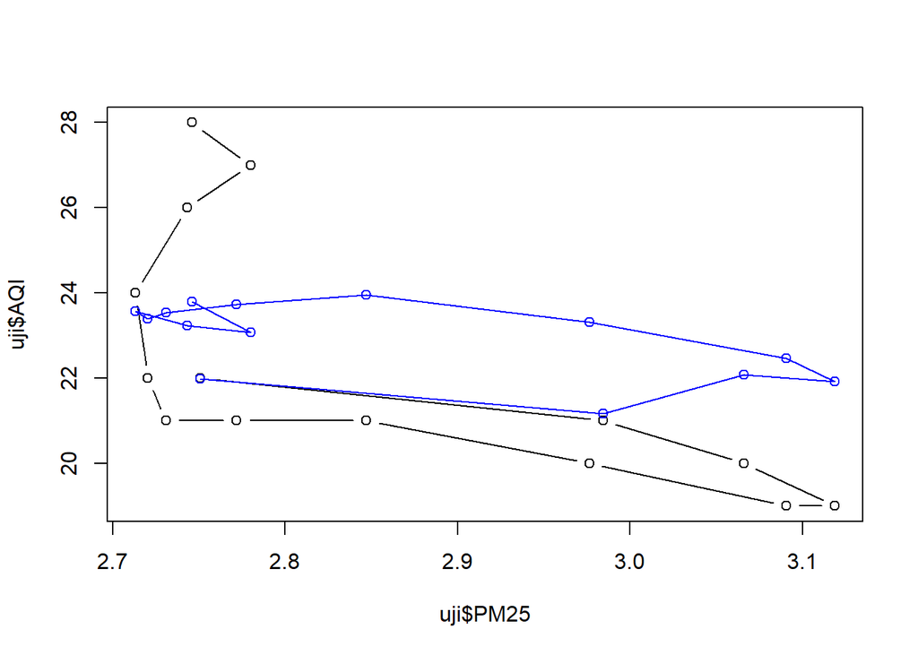

```r
plot(uji$PM25, uji$AQI, type="b", col="black")
points(uji$PM25, ramal.dist.lag$forecasts,col="blue")
lines(uji$PM25, ramal.dist.lag$forecasts,col="blue")
```

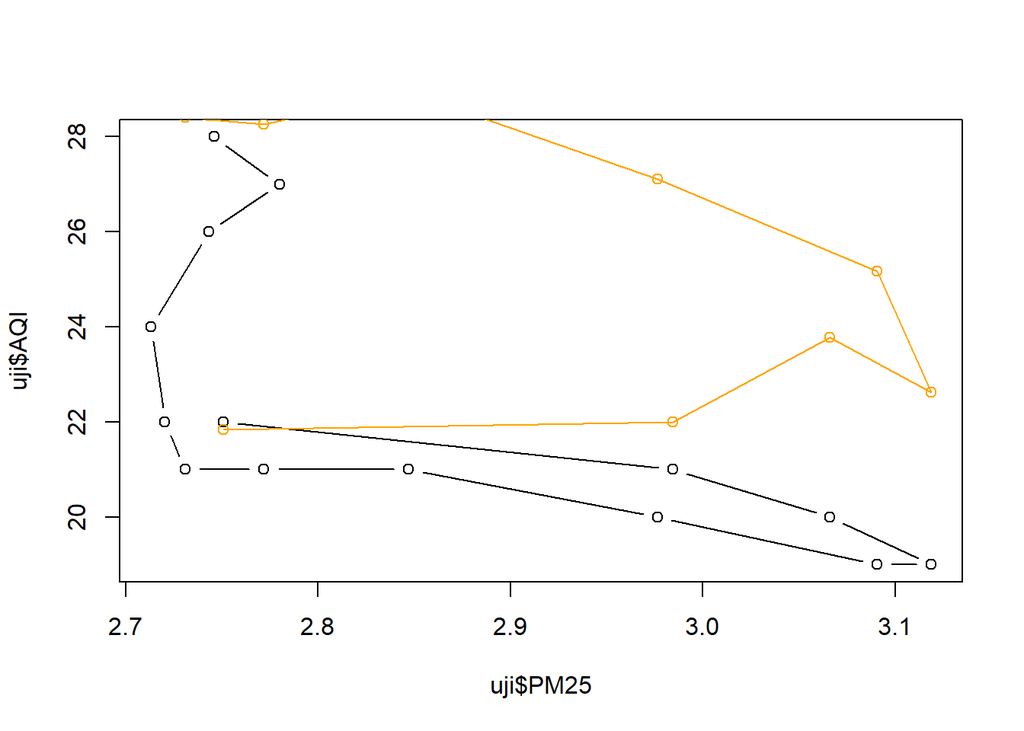

```r
plot(uji$PM25, uji$AQI, type="b", col="black")
points(uji$PM25, ramal.dist.lag2$forecasts,col="orange")
lines(uji$PM25, ramal.dist.lag2$forecasts,col="orange")
```

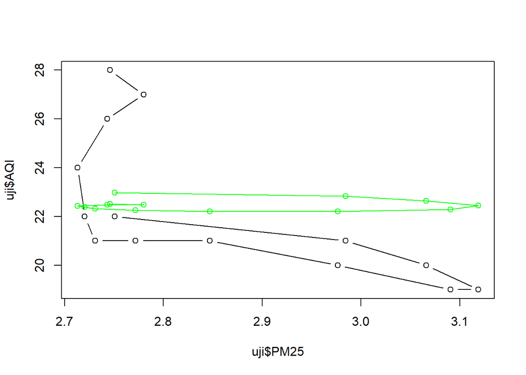

```r
plot(uji$PM25, uji$AQI, type="b", col="black")
points(uji$PM25, ramal.ardl$forecasts,col="green")
lines(uji$PM25, ramal.ardl$forecasts,col="green")
```

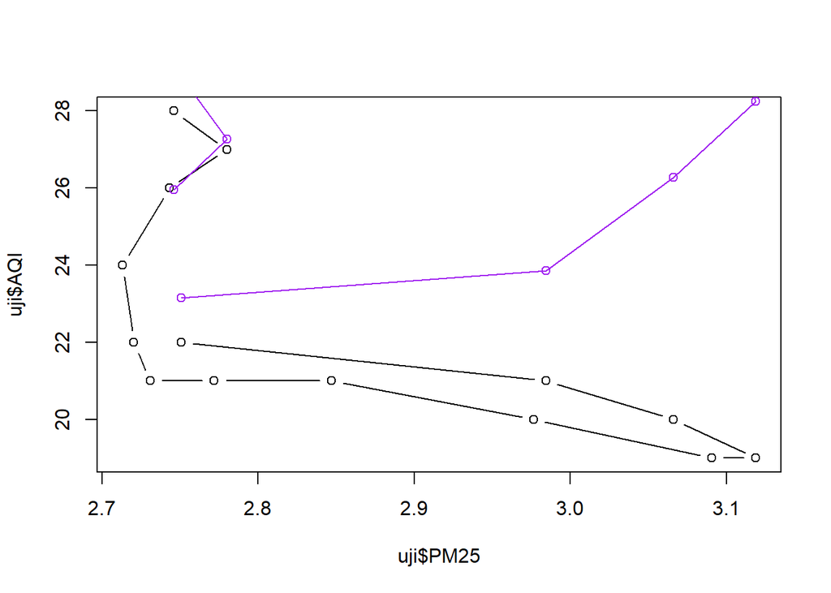

```r
plot(uji$PM25, uji$AQI, type="b", col="black")
points(uji$PM25, ramal.ardl2$forecasts,col="purple")
lines(uji$PM25, ramal.ardl2$forecasts,col="purple")
```

Berdasarkan plot tersebut, cukup sulit untuk menentukan plot mana yang paling mendekati data aktualnya. Dari kelima permalan, metode Koyck lah yang lebih cenderung mendekati pola pada aktualnya, meski sebenarnya cukup berbeda. Oleh karena itu, dapat disimpulkan model terbaik dalam hal ini adalah model regresi dengan metode Koyck.